# Medidas de Dispersión Datos Agrupados

Estadística Descriptiva

11/6/2020

## Tabla de Frecuencias con Intervalos

Si necesitamos calcular la varianza y la desviación estándar de un conjunto de datos agrupados por intervalos en un tabla de frecuencias, usaremos las fórmulas que revisaremos a continuación.

Para la varianza poblacional tenemos la siguiente fórmula

$$\sigma^2 = \frac{\sum_{i=1}^k f_i(x_i - \mu)^2}{N}$$

Donde:

- $k$: es el número de clases o intervalos en la tabla
- $f_i$: es la frecuencia absoluta de cada intervalo.
- $x_i$: marca de clase. Es el punto medio del límite inferior y del límite superior del intervalo.
- $\sigma^2$: varianza de la población.
- $\mu$: media de la población.

De forma similar podemos encontrar la desviación estándar de la población ($\sigma$), la varianza de la muestra ($S^2$) y la desviación estándar de la muestra ($S$).

$$S^2 = \frac{\sum_{i=1}^k f_i(x_i - \bar{x})^2}{n-1}$$

Teniendo en cuenta que $\bar{x}$ es la media de la muestra y $n$ es el tamaño de la muestra.

Para solucionar los divers problemas, seguiremos los siguientes pasos:

1. Calculamos el número de elementos.
2. Calculamos las marcas de clase.
3. Calculamos la media.
4. Calculamos la varianza.
5. Calculamos la desviación estándar, que es la raíz cuadrada de la varianza.

**Ejemplo:**

Calcular la varianza y la desviación estándar de una población de niños a partir de la siguiente tabla de frecuencia:

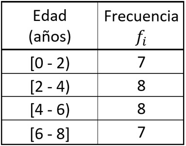

Como estamos hablando de una población de niños, encontraremos la varianza y la desviación estándar de una población.

Primero calculemos el número de elementos de la población:

$$N = \sum_{i=1}^k f_i = 7 + 8 + 8 + 7 = 30$$

Como segundo paso, calcularemos las marcas de clase. Recordemos que la marca de clase $x_i$, es el punto medio del límite inferior y el límite superior de cada intervalo. Se calcula con la siguiente fórmula:

$$x_i = \frac{L_i + L_s}{2}$$

Agregamos una columna más a nuestra tabla para la marca de clase $x_i$:

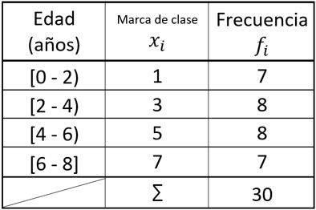

Como tercer paso, calculamos la media poblacional $\mu$:

$$\mu = \frac{\sum_{i=1}^k x_i \cdot f_i}{N} = \frac{120}{30} = 4 \textrm{ años}$$

La media poblacional $\mu$ tiene un valor de 4 años.

Como cuarto paso, calculamos la varianza de la población. Para ello agregamos más columnas a nuestra tabla, buscando la forma de la fórmula de la varianza:

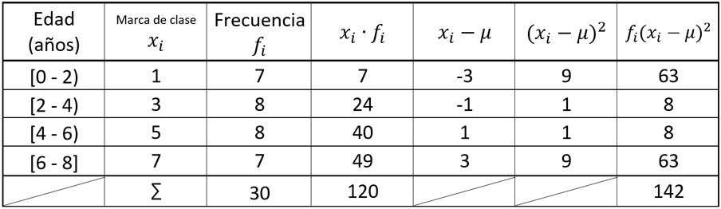

Aplicamos la fórmula de la varianza de la población:

$$\sigma^2 = \frac{\sum_{i=1}^k f_i(x_i - \mu)^2}{N} = \frac{142}{30} = 4.73$$

Como último paso, calculamos la desviación estándar, recordando que es la raíz cuadrada positiva de la varianza.

$$\sigma = \sqrt{\sigma^2} = \sqrt{4.73} = 2.175 \textrm{ años}$$

El valor de la desviación estándar poblacional $\sigma$ es de 2.175 años.

## Tabla de Frecuencias con Datos Puntuales

Si trabajamos con una tabla de frecuencias con datos agrupados de una variable discreta, es decir, la variable toma valores puntuales, no intervalos de valores, podemos calcular la varianza y la desviación estándar usando las fórmulas que veremos a continuación.

La fórmula a utilizar para la varianza poblacional y muestral es prácticamente la misma que utilizamos en la sección anterior, solo que no utilizamos la marca de clase, y en su lugar usamos el dato puntual que nos presenta la tabla de frecuencia en cada clase.

Entonces, en la fórmula:

$$\sigma^2 = \frac{\sum_{i=1}^k f_i(x_i - \mu)^2}{N} \\
S^2 = \frac{\sum_{i=1}^k f_i(x_i - \bar{x})^2}{n-1}$$

tenemos que:

- $f_i$: frecuencia absoluta de cada valor, es decir, número de veces que aparece el valor en el estudio.
- $x_i$: valor de los elementos de la población.
- $\sigma^2$: varianza de la población.
- $\sigma$: desviación estándar de la población.
- $\mu$: media poblacional.
- $s^2$: varianza de la muestra.
- $s$: desviación estándar de la muestra.
- $\bar{x}̄$: media de la muestra.
- $k$: número de clases.

En los problemas, seguiremos los siguientes pasos:

1. Calculamos el número de elementos.
2. Calculamos la media.
3. Calculamos la varianza.
4. Calculamos la desviación estándar, que es la raíz cuadrada de la varianza.

**Ejemplo**

Calcular la varianza y la desviación estándar de las edades de una población de niños que asisten a una fiesta infantil.

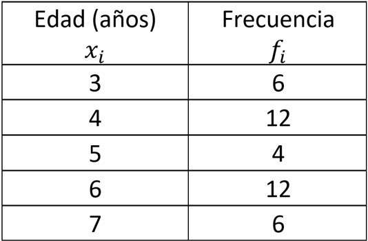

Para calcular la varianza y la desviación estándar, empezamos calculando el número de elementos de la población:

$$N = \sum_{i=1}^k f_i = 6 + 12 + 4 + 12 + 6 = 40$$

Y ahora calculamos la media poblacional. Comenzamos agregando una columna a la tabla de frecuencia que calcule $x_i \cdot f_i$:

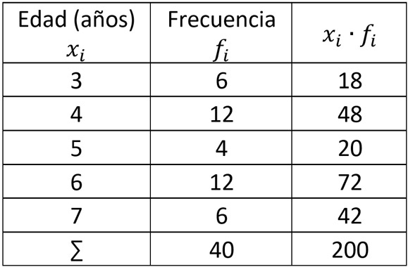

Y con esto, calculamos la media:

$$\mu = \frac{\sum_{i=1}^k x_i \cdot f_i}{N} = \frac{200}{40} = 5 \textrm{ años}$$

A continuación, agregamos 3 columnas más a la tabla de frecuencia buscando encontrar lo que necesitamos para calcular la varianza poblacional:

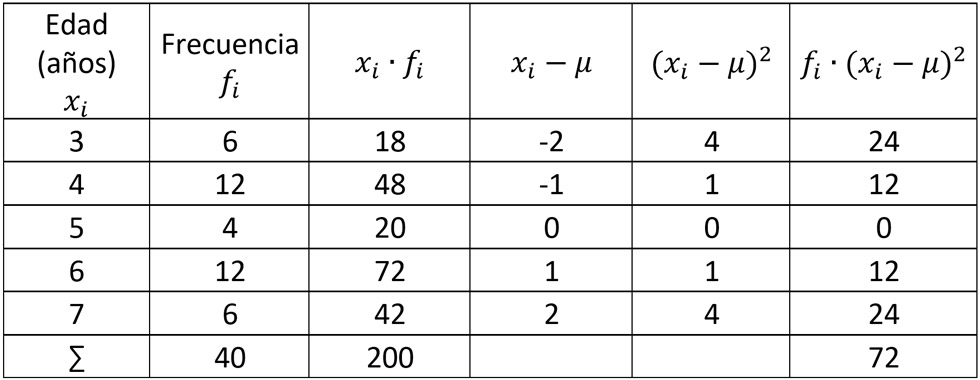

Usamos la fórmula:

$$\sigma^2 = \frac{\sum_{i=1}^k f_i(x_i - \mu)^2}{N} = \frac{72}{40} = 1.8$$

El valor de la varianza de esta población es de 1.8

Finalmente calculamos la desviación estándar, teniendo en cuenta que es la raíz cuadrada positiva de la varianza: $\sigma = \sqrt{\sigma^2} = \sqrt{1.8} = 1.34 \textrm{ años}$.